# Module 161

#### Hemi-module gene counts:

435 probesets in hemi-module A.  
38 probesets in hemi-module B.  
Note: While the mapping of probesets to genes is usually one-to-one, some genes are targeted by multiple probesets, some probesets target multiple genes, and some probesets do not target any genes (i.e., the region of the genome they match is no longer considered genic).

#### Contrast SVE:

Signed variance explained (SVE) provides an indication of how similar a set of fold changes are to a gene module’s weight vector. An SVE value of 0.3, for example, indicates that 30% of the variance explained by the entire module set is accounted for by the module in question. Shown here are the SVE values for this module across a compendium of fold changes (contrasts). Extreme SVE values (e.g., > 0.05) indicate that those contrasts specifically induce (orange dots) or specifically repress (blue dots) this module. Examining the experimental conditions being compared in such contrasts (see tables below the figure) may provide insight into the gene module’s function.

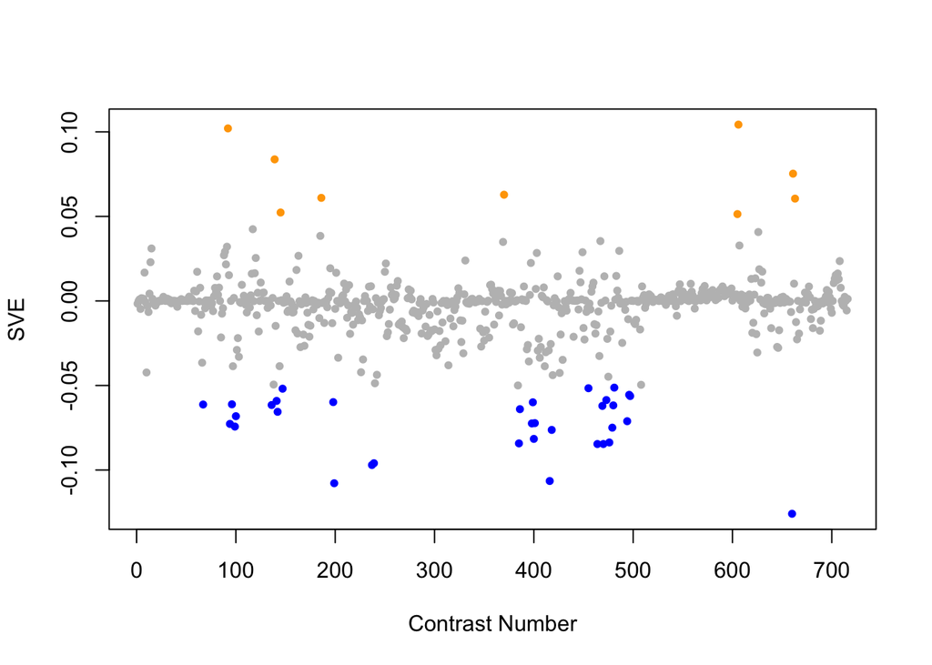

Positive SVE Contrasts:

|  | Contrast.Num | SVE | GEO.GSE | Cond.1 | Cond.2 | Mutation |
| --- | --- | --- | --- | --- | --- | --- |
| GSE21784.s1t1.vs.s3t1 | 606 | 0.10 | GSE21784 | L4 larvae, biological rep1 | day 15 adults, biological rep 1 |  |
| GSE5801.s2t1.vs.s1t1 | 92 | 0.10 | GSE5801 | daf2daf16_RepA | daf2_RepA | daf-16 |
| GSE51691.s3t1.vs.s2t1 | 139 | 0.08 | GSE51691 | day8 hermaphrodite utx-1 RNAi -males rep 1 | day8 hermaphrodite +males rep 1 |  |
| GSE15159.s1t1.vs.s0t1 | 661 | 0.08 | GSE15159 | glp-1_control_2007_rep1 | N2_control_2007_rep1 | glp-1 |
| GSE35360B.s2t1.vs.s0t1 | 370 | 0.06 | GSE35360 | HF 3d_2.0_rep1 | HF 3d control_rep1 |  |
| GSE4766.s1t2.vs.s1t1 | 186 | 0.06 | GSE4766 | Pooled glp-1 C elegans young adults_rep1 | Pooled glp-1 C elegans embryos_bleach NaOH prep_rep1 |  |
| GSE15159.s1t2.vs.s0t2 | 663 | 0.06 | GSE15159 | glp-1_UV_2007_rep1 | N2_UV_2007_rep1 | glp-1 |
| GSE50513.s3t1.vs.s2t1 | 145 | 0.05 | GSE50513 | zip-2 OP50 - rep 1 | L4440 PA14 - rep 1 |  |
| GSE21784.s2t1.vs.s3t1 | 605 | 0.05 | GSE21784 | day 6 adults, biological rep 1 | day 15 adults, biological rep 1 |  |

Negative SVE Contrasts:

|  | Contrast.Num | SVE | GEO.GSE | Cond.1 | Cond.2 | Mutation |
| --- | --- | --- | --- | --- | --- | --- |
| GSE15527.s2t1.vs.s1t1 | 660 | -0.13 | GSE15527 | sma-6 L4 worm, biological rep1 | dbl-1 L4 worm, biological rep1 | dbl-1 |
| GSE43959.s1t2.vs.s4t2 | 199 | -0.11 | GSE43959 | N2 gravid adult on E. coli OP50 rep 1 | N2 gravid adult on 1:1000 Comamonas DA1877 rep 1 |  |
| GSE29951.s0t2.vs.s0t1 | 416 | -0.11 | GSE29951 | C.elegans wild type raised in the presence of Cd, rep1 | C.elegans wild type raised in the absence of Cd, rep1 |  |
| GSE42592C.s3t2.vs.s0t2 | 237 | -0.10 | GSE42592 | mercury_high_expose-4h_rep1 | mercury_control_expose-4h_rep1 |  |
| GSE42592C.s2t2.vs.s0t2 | 239 | -0.10 | GSE42592 | mercury_mid_expose-4h_rep1 | mercury_control_expose-4h_rep1 |  |
| GSE23528A.s2t4.vs.s0t4 | 464 | -0.08 | GSE23528 | Adult at T14 in WC, time-series experiment 1 | Adult at T14, non-entrained control time-series experiment 4 |  |
| GSE23528A.s2t6.vs.s0t6 | 470 | -0.08 | GSE23528 | Adult at T22 in WC, time-series experiment 1 | Adult at T22, non-entrained control time-series experiment 4 |  |
| GSE34026.s3t1.vs.s0t1 | 385 | -0.08 | GSE34026 | N2 exposed to CVD110, biological rep1 | N2 exposed to OP50(E.coli), biological rep1 |  |
| GSE23528A.s1t6.vs.s1t1 | 476 | -0.08 | GSE23528 | Adult at T22 in LD, time-series experiment 3 | Adult at T2 in LD, time-series experiment 3 |  |
| GSE30505.s2t2.vs.s3t2 | 400 | -0.08 | GSE30505 | Day 8 N2 (WT) ash-2 #1 | Day 8 glp-1 E.V. #1 | ash-2(RNAi) vs. glp-1 |
| GSE28856.s0t3.vs.s0t1 | 418 | -0.08 | GSE28856 | Wild-type 2 h after shifting temperature rep1 | Wild-type 0 h after shifting temperature rep1 |  |
| GSE23528A.s2t4.vs.s2t1 | 479 | -0.07 | GSE23528 | Adult at T14 in WC, time-series experiment 1 | Adult at T2 in WC, time-series experiment 1 |  |
| GSE5793.s3t2.vs.s1t2 | 99 | -0.07 | GSE5793 | Celegans_PA14_8hours_RepA | Celegans_gacA_8hours_RepA |  |
| GSE5801.s3t1.vs.s2t1 | 94 | -0.07 | GSE5801 | daf2pmk1_RepA | daf2daf16_RepA |  |
| GSE30505.s2t2.vs.s4t2 | 398 | -0.07 | GSE30505 | Day 8 N2 (WT) ash-2 #1 | Day 8 glp-1 ash-2 #1 | glp-1 |
| GSE30505.s1t2.vs.s3t2 | 401 | -0.07 | GSE30505 | Day 8 N2 (WT) E.V. #1 | Day 8 glp-1 E.V. #1 | glp-1 |
| GSE23528C.s1t3.vs.s1t1 | 494 | -0.07 | GSE23528 | Adult at T34 in DD, time-series experiment 2 | Adult at T26 in DD, time-series experiment 2 |  |
| GSE5793.s3t2.vs.s2t2 | 100 | -0.07 | GSE5793 | Celegans_PA14_8hours_RepA | Celegans_OP50_8hours_RepA |  |
| GSE50513.s2t1.vs.s1t1 | 142 | -0.07 | GSE50513 | L4440 PA14 - rep 1 | L4440 OP50 - rep 1 |  |
| GSE34026.s2t1.vs.s0t1 | 386 | -0.06 | GSE34026 | N2 exposed to E7946, biological rep1 | N2 exposed to OP50(E.coli), biological rep1 |  |
| GSE23528A.s1t6.vs.s0t6 | 469 | -0.06 | GSE23528 | Adult at T22 in LD, time-series experiment 3 | Adult at T22, non-entrained control time-series experiment 4 |  |
| GSE23528A.s2t5.vs.s2t1 | 480 | -0.06 | GSE23528 | Adult at T18 in WC, time-series experiment 1 | Adult at T2 in WC, time-series experiment 1 |  |
| GSE51691.s2t1.vs.s1t1 | 136 | -0.06 | GSE51691 | day8 hermaphrodite +males rep 1 | day8 hermaphrodite -males rep 1 |  |
| GSE8659.s3t1.vs.s2t1 | 67 | -0.06 | GSE8659 | strain NL 2099 replicate 2 | strain GR1373 replicate 1 |  |
| GSE5793.s3t1.vs.s1t1 | 96 | -0.06 | GSE5793 | Celegans_PA14_4hours_RepA | Celegans_gacA_4hours_RepA |  |
| GSE30505.s1t2.vs.s4t2 | 399 | -0.06 | GSE30505 | Day 8 N2 (WT) E.V. #1 | Day 8 glp-1 ash-2 #1 | glp-1; ash-2 |
| GSE43959.s3t2.vs.s4t2 | 198 | -0.06 | GSE43959 | N2 gravid adult on Comamonas DA1877 rep 1 | N2 gravid adult on 1:1000 Comamonas DA1877 rep 1 |  |
| GSE51691.s4t1.vs.s3t1 | 141 | -0.06 | GSE51691 | day8 hermaphrodite utx-1 RNAi +males rep 1 | day8 hermaphrodite utx-1 RNAi -males rep 1 |  |
| GSE23528A.s1t3.vs.s1t1 | 473 | -0.06 | GSE23528 | Adult at T10 in LD, time-series experiment 3 | Adult at T2 in LD, time-series experiment 3 |  |
| GSE23528C.s1t6.vs.s1t1 | 497 | -0.06 | GSE23528 | Adult at T46 in DD, time-series experiment 2 | Adult at T26 in DD, time-series experiment 2 |  |
| GSE23528C.s1t5.vs.s1t1 | 496 | -0.06 | GSE23528 | Adult at T42 in DD, time-series experiment 2 | Adult at T26 in DD, time-series experiment 2 |  |
| GSE50513.s4t1.vs.s3t1 | 147 | -0.05 | GSE50513 | zip-2 PA14 - rep 1 | zip-2 OP50 - rep 1 |  |
| GSE25513.s1t1.vs.s0t1 | 455 | -0.05 | GSE25513 | tax-6 null (1) | WT (1) | tax-6 |
| GSE23528A.s2t6.vs.s2t1 | 481 | -0.05 | GSE23528 | Adult at T22 in WC, time-series experiment 1 | Adult at T2 in WC, time-series experiment 1 |  |

$~$

#### Contrast SVE, Up-Regulated Genes Only:

Calculating SVE for up-regulated and down-regulated genes separately may be more informative in many cases than projecting the up- and down- gene sets together. This is due to the fact that the weight distribution of many modules is highly skewed, indicating that only one of the hemi-modules may be biologically meaningful (i.e., a set of genes are strongly correlated by only a few genes (or none) are strongly anti-correlated to that set.)

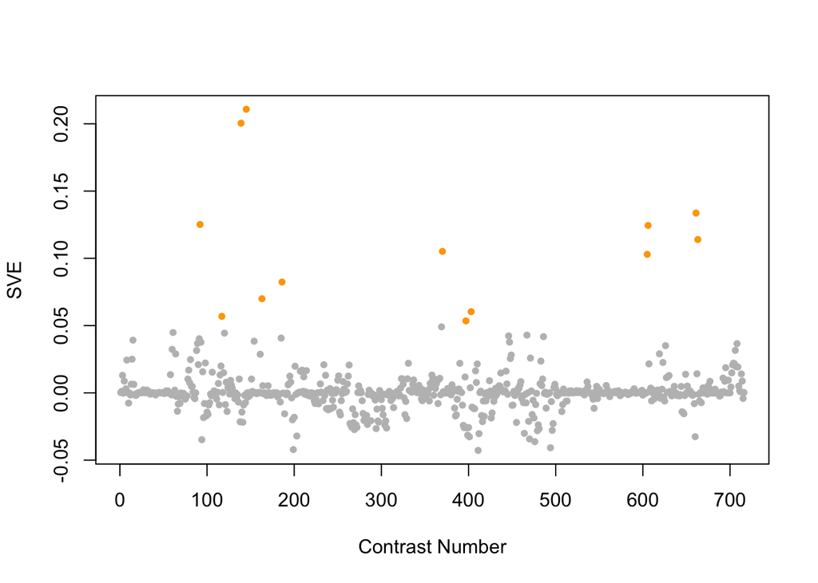

Positive SVE Contrasts:

|  | Contrast.Num | SVE | GEO.GSE | Cond.1 | Cond.2 | Mutation |
| --- | --- | --- | --- | --- | --- | --- |
| GSE50513.s3t1.vs.s2t1 | 145 | 0.21 | GSE50513 | zip-2 OP50 - rep 1 | L4440 PA14 - rep 1 |  |
| GSE51691.s3t1.vs.s2t1 | 139 | 0.20 | GSE51691 | day8 hermaphrodite utx-1 RNAi -males rep 1 | day8 hermaphrodite +males rep 1 |  |
| GSE15159.s1t1.vs.s0t1 | 661 | 0.13 | GSE15159 | glp-1_control_2007_rep1 | N2_control_2007_rep1 | glp-1 |
| GSE5801.s2t1.vs.s1t1 | 92 | 0.13 | GSE5801 | daf2daf16_RepA | daf2_RepA | daf-16 |
| GSE21784.s1t1.vs.s3t1 | 606 | 0.12 | GSE21784 | L4 larvae, biological rep1 | day 15 adults, biological rep 1 |  |
| GSE15159.s1t2.vs.s0t2 | 663 | 0.11 | GSE15159 | glp-1_UV_2007_rep1 | N2_UV_2007_rep1 | glp-1 |
| GSE35360B.s2t1.vs.s0t1 | 370 | 0.11 | GSE35360 | HF 3d_2.0_rep1 | HF 3d control_rep1 |  |
| GSE21784.s2t1.vs.s3t1 | 605 | 0.10 | GSE21784 | day 6 adults, biological rep 1 | day 15 adults, biological rep 1 |  |
| GSE4766.s1t2.vs.s1t1 | 186 | 0.08 | GSE4766 | Pooled glp-1 C elegans young adults_rep1 | Pooled glp-1 C elegans embryos_bleach NaOH prep_rep1 |  |
| GSE47778.s4t2.vs.s2t2 | 163 | 0.07 | GSE47778 | daf-2;daf-16; starvation; replicate 1 | daf-2; starvation; replicate 1 | daf-2;daf-16 vs. daf-2 |
| GSE30505.s3t1.vs.s4t1 | 403 | 0.06 | GSE30505 | L3 glp-1 E.V. #1 | L3 glp-1 ash-2 #1 | ash-2 |
| GSE54024.s3t1.vs.s6t1 | 117 | 0.06 | GSE54024 | nuo-6(qm200) young adults, biological rep 1 | isp-1(qm150) ced-4(n1162) double mutant young adults, biological rep 1 |  |
| GSE30505.s3t2.vs.s4t2 | 397 | 0.05 | GSE30505 | Day 8 glp-1 E.V. #1 | Day 8 glp-1 ash-2 #1 | ash-2 |

Negative SVE Contrasts:

|  | Contrast.Num | SVE | GEO.GSE | Cond.1 | Cond.2 | Mutation |
| --- | --- | --- | --- | --- | --- | --- |
| GSE30505.s2t2.vs.s2t1 | 411 | -0.04 | GSE30505 | Day 8 N2 (WT) ash-2 #1 | L3 N2 (WT) ash-2 #1 |  |
| GSE43959.s1t2.vs.s4t2 | 199 | -0.04 | GSE43959 | N2 gravid adult on E. coli OP50 rep 1 | N2 gravid adult on 1:1000 Comamonas DA1877 rep 1 |  |
| GSE23528C.s1t3.vs.s1t1 | 494 | -0.04 | GSE23528 | Adult at T34 in DD, time-series experiment 2 | Adult at T26 in DD, time-series experiment 2 |  |
| GSE23528A.s1t6.vs.s1t1 | 476 | -0.04 | GSE23528 | Adult at T22 in LD, time-series experiment 3 | Adult at T2 in LD, time-series experiment 3 |  |
| GSE5801.s3t1.vs.s2t1 | 94 | -0.03 | GSE5801 | daf2pmk1_RepA | daf2daf16_RepA |  |

$~$

#### Contrast SVE, Down-Regulated Genes Only:

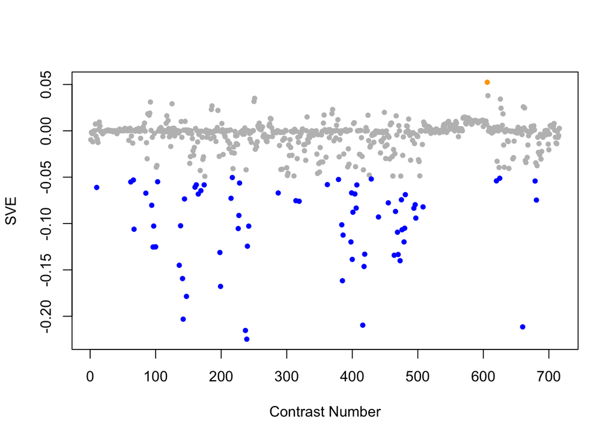

Positive SVE Contrasts:

|  | Contrast.Num | SVE | GEO.GSE | Cond.1 | Cond.2 | Mutation |
| --- | --- | --- | --- | --- | --- | --- |
| GSE21784.s1t1.vs.s3t1 | 606 | 0.05 | GSE21784 | L4 larvae, biological rep1 | day 15 adults, biological rep 1 |  |
| GSE21784.s1t1.vs.s2t1 | 607 | 0.04 | GSE21784 | L4 larvae, biological rep1 | day 6 adults, biological rep 1 |  |
| GSE42192.s2t1.vs.s0t1 | 251 | 0.04 | GSE42192 | C.elegans fed with CNCM I-4317 3 days rep1 | C.elegans fed with E.coli OP50 3 days rep1 |  |
| GSE19310A.s4t1.vs.s0t1 | 626 | 0.03 | GSE19310 | dpy-10(e128) at iso, rep3 | N2 at iso, rep1 | dpy-10 |
| GSE42192.s1t1.vs.s0t1 | 250 | 0.03 | GSE42192 | C.elegans fed with CNCM I-3690 3 days rep1 | C.elegans fed with E.coli OP50 3 days rep1 |  |

Negative SVE Contrasts:

|  | Contrast.Num | SVE | GEO.GSE | Cond.1 | Cond.2 | Mutation |
| --- | --- | --- | --- | --- | --- | --- |
| GSE42592C.s2t2.vs.s0t2 | 239 | -0.22 | GSE42592 | mercury_mid_expose-4h_rep1 | mercury_control_expose-4h_rep1 |  |
| GSE42592C.s3t2.vs.s0t2 | 237 | -0.22 | GSE42592 | mercury_high_expose-4h_rep1 | mercury_control_expose-4h_rep1 |  |
| GSE15527.s2t1.vs.s1t1 | 660 | -0.21 | GSE15527 | sma-6 L4 worm, biological rep1 | dbl-1 L4 worm, biological rep1 | dbl-1 |
| GSE29951.s0t2.vs.s0t1 | 416 | -0.21 | GSE29951 | C.elegans wild type raised in the presence of Cd, rep1 | C.elegans wild type raised in the absence of Cd, rep1 |  |
| GSE50513.s2t1.vs.s1t1 | 142 | -0.20 | GSE50513 | L4440 PA14 - rep 1 | L4440 OP50 - rep 1 |  |
| GSE50513.s4t1.vs.s3t1 | 147 | -0.18 | GSE50513 | zip-2 PA14 - rep 1 | zip-2 OP50 - rep 1 |  |
| GSE43959.s1t2.vs.s4t2 | 199 | -0.17 | GSE43959 | N2 gravid adult on E. coli OP50 rep 1 | N2 gravid adult on 1:1000 Comamonas DA1877 rep 1 |  |
| GSE34026.s3t1.vs.s0t1 | 385 | -0.16 | GSE34026 | N2 exposed to CVD110, biological rep1 | N2 exposed to OP50(E.coli), biological rep1 |  |
| GSE51691.s4t1.vs.s3t1 | 141 | -0.16 | GSE51691 | day8 hermaphrodite utx-1 RNAi +males rep 1 | day8 hermaphrodite utx-1 RNAi -males rep 1 |  |
| GSE28856.s0t3.vs.s0t1 | 418 | -0.15 | GSE28856 | Wild-type 2 h after shifting temperature rep1 | Wild-type 0 h after shifting temperature rep1 |  |
| GSE51691.s2t1.vs.s1t1 | 136 | -0.15 | GSE51691 | day8 hermaphrodite +males rep 1 | day8 hermaphrodite -males rep 1 |  |
| GSE23528A.s1t3.vs.s1t1 | 473 | -0.14 | GSE23528 | Adult at T10 in LD, time-series experiment 3 | Adult at T2 in LD, time-series experiment 3 |  |
| GSE30505.s2t2.vs.s3t2 | 400 | -0.14 | GSE30505 | Day 8 N2 (WT) ash-2 #1 | Day 8 glp-1 E.V. #1 | ash-2(RNAi) vs. glp-1 |
| GSE23528A.s2t4.vs.s0t4 | 464 | -0.13 | GSE23528 | Adult at T14 in WC, time-series experiment 1 | Adult at T14, non-entrained control time-series experiment 4 |  |
| GSE23528A.s2t6.vs.s0t6 | 470 | -0.13 | GSE23528 | Adult at T22 in WC, time-series experiment 1 | Adult at T22, non-entrained control time-series experiment 4 |  |
| GSE28856.s0t4.vs.s0t1 | 419 | -0.13 | GSE28856 | Wild-type 4 h after shifting temperature rep1 | Wild-type 0 h after shifting temperature rep1 |  |
| GSE43959.s3t2.vs.s4t2 | 198 | -0.13 | GSE43959 | N2 gravid adult on Comamonas DA1877 rep 1 | N2 gravid adult on 1:1000 Comamonas DA1877 rep 1 |  |
| GSE5793.s3t1.vs.s1t1 | 96 | -0.13 | GSE5793 | Celegans_PA14_4hours_RepA | Celegans_gacA_4hours_RepA |  |
| GSE5793.s3t2.vs.s1t2 | 99 | -0.13 | GSE5793 | Celegans_PA14_8hours_RepA | Celegans_gacA_8hours_RepA |  |
| GSE5793.s3t2.vs.s2t2 | 100 | -0.13 | GSE5793 | Celegans_PA14_8hours_RepA | Celegans_OP50_8hours_RepA |  |
| GSE42592C.s3t3.vs.s0t3 | 240 | -0.12 | GSE42592 | mercury_high_expose-8h_rep1 | mercury_control_expose-8h_rep1 |  |
| GSE30505.s2t2.vs.s4t2 | 398 | -0.12 | GSE30505 | Day 8 N2 (WT) ash-2 #1 | Day 8 glp-1 ash-2 #1 | glp-1 |
| GSE23528A.s2t4.vs.s2t1 | 479 | -0.12 | GSE23528 | Adult at T14 in WC, time-series experiment 1 | Adult at T2 in WC, time-series experiment 1 |  |
| GSE34026.s2t1.vs.s0t1 | 386 | -0.11 | GSE34026 | N2 exposed to E7946, biological rep1 | N2 exposed to OP50(E.coli), biological rep1 |  |
| GSE23528A.s1t6.vs.s0t6 | 469 | -0.11 | GSE23528 | Adult at T22 in LD, time-series experiment 3 | Adult at T22, non-entrained control time-series experiment 4 |  |
| GSE23528A.s1t6.vs.s1t1 | 476 | -0.11 | GSE23528 | Adult at T22 in LD, time-series experiment 3 | Adult at T2 in LD, time-series experiment 3 |  |
| GSE8659.s3t1.vs.s2t1 | 67 | -0.11 | GSE8659 | strain NL 2099 replicate 2 | strain GR1373 replicate 1 |  |
| GSE42592B.s3t2.vs.s0t2 | 226 | -0.11 | GSE42592 | cadmium_high_expose-4h_rep1 | cadmium_control_expose-4h_rep1 |  |
| GSE23528A.s2t5.vs.s2t1 | 480 | -0.11 | GSE23528 | Adult at T18 in WC, time-series experiment 1 | Adult at T2 in WC, time-series experiment 1 |  |
| GSE42592C.s2t3.vs.s0t3 | 242 | -0.10 | GSE42592 | mercury_mid_expose-8h_rep1 | mercury_control_expose-8h_rep1 |  |
| GSE5793.s3t1.vs.s2t1 | 97 | -0.10 | GSE5793 | Celegans_PA14_4hours_RepA | Celegans_OP50_4hours_RepA |  |
| GSE51691.s4t1.vs.s1t1 | 138 | -0.10 | GSE51691 | day8 hermaphrodite utx-1 RNAi +males rep 1 | day8 hermaphrodite -males rep 1 |  |
| GSE34026.s4t1.vs.s0t1 | 384 | -0.10 | GSE34026 | N2 exposed to CVD109, biological rep1 | N2 exposed to OP50(E.coli), biological rep1 |  |
| GSE23528C.s1t6.vs.s1t1 | 497 | -0.09 | GSE23528 | Adult at T46 in DD, time-series experiment 2 | Adult at T26 in DD, time-series experiment 2 |  |
| GSE27677B.s1t2.vs.s1t1 | 440 | -0.09 | GSE27677 | N2, Fast 3 h, rep 1 | N2, Fed 0 h, rep 1 |  |
| GSE42592B.s1t2.vs.s0t2 | 227 | -0.09 | GSE42592 | cadmium_low_expose-4h_rep1 | cadmium_control_expose-4h_rep1 |  |
| GSE30505.s1t2.vs.s3t2 | 401 | -0.09 | GSE30505 | Day 8 N2 (WT) E.V. #1 | Day 8 glp-1 E.V. #1 | glp-1 |
| GSE23528A.s2t5.vs.s0t5 | 466 | -0.09 | GSE23528 | Adult at T18 in WC, time-series experiment 1 | Adult at T18, non-entrained control time-series experiment 4 |  |
| GSE23528C.s1t3.vs.s1t1 | 494 | -0.08 | GSE23528 | Adult at T34 in DD, time-series experiment 2 | Adult at T26 in DD, time-series experiment 2 |  |
| GSE30505.s2t1.vs.s3t1 | 406 | -0.08 | GSE30505 | L3 N2 (WT) ash-2 #1 | L3 glp-1 E.V. #1 | ash-2(RNAi) vs. glp-1 |
| GSE21819.s1t1.vs.s0t1 | 508 | -0.08 | GSE21819 | CELEGANS_RN6390_8H_REP1 | CELEGANS_OP50_8H_REP1 |  |
| GSE5801.s3t1.vs.s2t1 | 94 | -0.08 | GSE5801 | daf2pmk1_RepA | daf2daf16_RepA |  |
| GSE23528C.s1t5.vs.s1t1 | 496 | -0.08 | GSE23528 | Adult at T42 in DD, time-series experiment 2 | Adult at T26 in DD, time-series experiment 2 |  |
| GSE25513.s1t1.vs.s0t1 | 455 | -0.08 | GSE25513 | tax-6 null (1) | WT (1) | tax-6 |
| GSE39012.s1t1.vs.s0t1 | 319 | -0.08 | GSE39012 | L3 stage worm AS_.03, biological replicate 1 | L3 stage worm AS_Control, biological replicate 1 |  |
| GSE41056.s2t2.vs.s2t1 | 314 | -0.08 | GSE41056 | RDE_1_inf_1 | RDE_1_1 |  |
| GSE12298A.s2t1.vs.s0t1 | 681 | -0.07 | GSE12298 | dichlorvos_mid_dose-rep1 | dichlorvos_control-rep1 |  |
| GSE23528A.s1t5.vs.s1t1 | 475 | -0.07 | GSE23528 | Adult at T18 in LD, time-series experiment 3 | Adult at T2 in LD, time-series experiment 3 |  |
| GSE50513.s4t1.vs.s1t1 | 144 | -0.07 | GSE50513 | zip-2 PA14 - rep 1 | L4440 OP50 - rep 1 |  |
| GSE42592A.s3t2.vs.s0t2 | 215 | -0.07 | GSE42592 | acrylamide_high_expose-4h_rep1 | acrylamide_control_expose-4h_rep1 |  |
| GSE23528A.s2t6.vs.s2t1 | 481 | -0.07 | GSE23528 | Adult at T22 in WC, time-series experiment 1 | Adult at T2 in WC, time-series experiment 1 |  |
| GSE47778.s1t2.vs.s4t2 | 165 | -0.07 | GSE47778 | N2; starvation; replicate 1 | daf-2;daf-16; starvation; replicate 1 | daf-2;daf-16 |
| GSE30505.s2t1.vs.s4t1 | 404 | -0.07 | GSE30505 | L3 N2 (WT) ash-2 #1 | L3 glp-1 ash-2 #1 | glp-1 |
| GSE6547.s1t2.vs.s0t2 | 85 | -0.07 | GSE6547 | lin-35(n745) worms at L1 stage, first replicate | N2 (wt) worms at L1 stage, first replicate | lin-35 |
| GSE41366C.s2t4.vs.s0t4 | 287 | -0.07 | GSE41366 | high_DDVP-continuous_expose-20h_harvest-rep1 | control-continuous_expose-14h_harvest-rep1 |  |
| GSE30505.s1t2.vs.s4t2 | 399 | -0.07 | GSE30505 | Day 8 N2 (WT) E.V. #1 | Day 8 glp-1 ash-2 #1 | glp-1; ash-2 |
| GSE47778.s5t3.vs.s3t3 | 169 | -0.06 | GSE47778 | xpa-1 10mJ/cm2; replicate 1 | daf-16; UV; replicate 1 | xpa-1 vs. daf-16 |
| GSE9682.s1t1.vs.s0t1 | 10 | -0.06 | GSE9682 | N2-Cel-RhebRNAi-fasting-biological rep1 | N2-controlRNAi-fasting-biological rep1 | Rheb |
| GSE47778.s2t2.vs.s3t2 | 160 | -0.06 | GSE47778 | daf-2; starvation; replicate 1 | daf-16; starvation; replicate 1 | daf-2 vs. daf-16 |
| GSE30505.s1t1.vs.s3t1 | 407 | -0.06 | GSE30505 | L3 N2 (WT) E.V. #1 | L3 glp-1 E.V. #1 | glp-1 |
| GSE47778.s5t3.vs.s4t3 | 174 | -0.06 | GSE47778 | xpa-1 10mJ/cm2; replicate 1 | daf-2;daf-16; UV; replicate 1 | xpa-1 vs. daf-2;daf-16 |
| GSE47778.s1t2.vs.s3t2 | 162 | -0.06 | GSE47778 | N2; starvation; replicate 1 | daf-16; starvation; replicate 1 | daf-16 |
| GSE37266.s1t1.vs.s0t1 | 362 | -0.06 | GSE37266 | RPW-24 G | DMSO G |  |
| GSE42592B.s2t2.vs.s0t2 | 228 | -0.06 | GSE42592 | cadmium_mid_expose-4h_rep1 | cadmium_control_expose-4h_rep1 |  |
| GSE8696.s1t1.vs.s2t1 | 62 | -0.06 | GSE8696 | 4 uM hemin (4A) | 20 uM hemin (20A) |  |
| GSE5793.s3t2.vs.s3t1 | 103 | -0.05 | GSE5793 | Celegans_PA14_8hours_RepA | Celegans_PA14_4hours_RepA |  |
| GSE12298A.s3t1.vs.s0t1 | 679 | -0.05 | GSE12298 | dichlorvos_high_dose-rep1 | dichlorvos_control-rep1 |  |
| GSE21376.s1t1.vs.s0t1 | 620 | -0.05 | GSE21376 | L1 larvae treated with let-418(RNAi), replicate 1 | L1 larvae treated with gfp(RNAi), replicate 1 | let-418 |
| GSE8659.s3t1.vs.s1t1 | 66 | -0.05 | GSE8659 | strain NL 2099 replicate 2 | N2 replicate 1 | rrf-3 |
| GSE34471.s1t2.vs.s0t2 | 379 | -0.05 | GSE34471 | 20uM-Exp1 | 20uM-Con-1 | hrg-2 |
| GSE27677A.s2t1.vs.s0t1 | 429 | -0.05 | GSE27677 | jun-1, Fed , rep 1 | N2, Fed , rep 1 | 40694 |
| GSE19972.s2t1.vs.s0t1 | 625 | -0.05 | GSE19972 | transgenic myo-4::his-SUMO-1 JS63_1 | control wild type N2_1 |  |
| GSE42592A.s2t2.vs.s0t2 | 217 | -0.05 | GSE42592 | acrylamide_mid_expose-4h_rep1 | acrylamide_control_expose-4h_rep1 |  |

$~$

$~$

#### GO Term Enrichment:

This analysis tests each hemi-module for enrichment of specific GO terms. Only gene-level annotations (e.g., as would be found on the gene’s page in Wormbase) are tested - the hierarchical structure of the GO ontology is not taken into account.

*Note: At least the top two most enriched terms from each GO domain (BP/MF/CC) are shown, even when not statistically significant.*

##### Enriched GO terms: Hemi-module A

| ID | GO.Term | GO Domain | Raw p-value | Adj p-value |
| --- | --- | --- | --- | --- |
| [GO_0055085](http://amigo.geneontology.org/amigo/term/GO:0055085) | transmembrane transport | BP | 1.81e-17 | 6.58e-14 |
| [GO_0055114](http://amigo.geneontology.org/amigo/term/GO:0055114) | oxidation-reduction process | BP | 5.47e-08 | 9.96e-05 |
| [GO_0006629](http://amigo.geneontology.org/amigo/term/GO:0006629) | lipid metabolic process | BP | 1.51e-06 | 1.83e-03 |
| [GO_0006189](http://amigo.geneontology.org/amigo/term/GO:0006189) | ‘de novo’ IMP biosynthetic process | BP | 5.54e-06 | 5.04e-03 |
| [GO_0006631](http://amigo.geneontology.org/amigo/term/GO:0006631) | fatty acid metabolic process | BP | 3.49e-05 | 2.54e-02 |
| [GO_0034755](http://amigo.geneontology.org/amigo/term/GO:0034755) | iron ion transmembrane transport | BP | 7.16e-05 | 4.35e-02 |
| [GO_0006164](http://amigo.geneontology.org/amigo/term/GO:0006164) | purine nucleotide biosynthetic process | BP | 1.10e-04 | 5.74e-02 |
| [GO_0022857](http://amigo.geneontology.org/amigo/term/GO:0022857) | transmembrane transporter activity | MF | 2.97e-10 | 6.07e-07 |
| [GO_0005515](http://amigo.geneontology.org/amigo/term/GO:0005515) | protein binding | MF | 2.75e-09 | 2.81e-06 |
| [GO_0016491](http://amigo.geneontology.org/amigo/term/GO:0016491) | oxidoreductase activity | MF | 1.49e-08 | 1.01e-05 |
| [GO_0008194](http://amigo.geneontology.org/amigo/term/GO:0008194) | UDP-glycosyltransferase activity | MF | 4.38e-06 | 2.24e-03 |
| [GO_0016758](http://amigo.geneontology.org/amigo/term/GO:0016758) | transferase activity, transferring hexosyl groups | MF | 1.12e-05 | 4.59e-03 |
| [GO_0003723](http://amigo.geneontology.org/amigo/term/GO:0003723) | RNA binding | MF | 3.52e-05 | 1.20e-02 |
| [GO_0008239](http://amigo.geneontology.org/amigo/term/GO:0008239) | dipeptidyl-peptidase activity | MF | 7.16e-05 | 2.09e-02 |
| [GO_0005506](http://amigo.geneontology.org/amigo/term/GO:0005506) | iron ion binding | MF | 1.11e-04 | 2.84e-02 |
| [GO_0003676](http://amigo.geneontology.org/amigo/term/GO:0003676) | nucleic acid binding | MF | 1.68e-04 | 3.80e-02 |
| [GO_0005381](http://amigo.geneontology.org/amigo/term/GO:0005381) | iron ion transmembrane transporter activity | MF | 2.93e-04 | 5.99e-02 |
| [GO_0004497](http://amigo.geneontology.org/amigo/term/GO:0004497) | monooxygenase activity | MF | 3.75e-04 | 6.89e-02 |
| [GO_0052689](http://amigo.geneontology.org/amigo/term/GO:0052689) | carboxylic ester hydrolase activity | MF | 4.05e-04 | 6.89e-02 |
| [GO_0015020](http://amigo.geneontology.org/amigo/term/GO:0015020) | glucuronosyltransferase activity | MF | 5.80e-04 | 7.99e-02 |
| [GO_0004854](http://amigo.geneontology.org/amigo/term/GO:0004854) | xanthine dehydrogenase activity | MF | 6.24e-04 | 7.99e-02 |
| [GO_0046592](http://amigo.geneontology.org/amigo/term/GO:0046592) | polyamine oxidase activity | MF | 6.24e-04 | 7.99e-02 |
| [GO_0016757](http://amigo.geneontology.org/amigo/term/GO:0016757) | transferase activity, transferring glycosyl groups | MF | 6.26e-04 | 7.99e-02 |
| [GO_0005634](http://amigo.geneontology.org/amigo/term/GO:0005634) | nucleus | CC | 7.14e-09 | 6.63e-06 |
| [GO_0016021](http://amigo.geneontology.org/amigo/term/GO:0016021) | integral component of membrane | CC | 1.91e-07 | 8.84e-05 |
| [GO_0016020](http://amigo.geneontology.org/amigo/term/GO:0016020) | membrane | CC | 1.09e-06 | 3.37e-04 |
| [GO_0043231](http://amigo.geneontology.org/amigo/term/GO:0043231) | intracellular membrane-bounded organelle | CC | 9.88e-05 | 2.29e-02 |

##### Enriched GO terms: Hemi-module B

| ID | GO.Term | GO Domain | Raw p-value | Adj p-value |
| --- | --- | --- | --- | --- |
| [GO_0045087](http://amigo.geneontology.org/amigo/term/GO:0045087) | innate immune response | BP | 2.50e-07 | 9.11e-04 |
| [GO_0019835](http://amigo.geneontology.org/amigo/term/GO:0019835) | cytolysis | BP | 2.90e-05 | 5.29e-02 |
| [GO_0003796](http://amigo.geneontology.org/amigo/term/GO:0003796) | lysozyme activity | MF | 2.16e-04 | 4.41e-01 |
| [GO_0070513](http://amigo.geneontology.org/amigo/term/GO:0070513) | death domain binding | MF | 2.24e-03 | 1.00e+00 |
| [GO_0005634](http://amigo.geneontology.org/amigo/term/GO:0005634) | nucleus | CC | 6.52e-03 | 1.00e+00 |
| [GO_0046930](http://amigo.geneontology.org/amigo/term/GO:0046930) | pore complex | CC | 8.95e-03 | 1.00e+00 |

$~$

$~$

#### Tissue Enrichment:

This analysis tests each hemi-module for enrichment of genes associated with anatomy terms. Negative enrichment scores indicate fewer hemi-module genes than expected by random chance were associated with the anatomy term in question.

##### Enriched tissues: Hemi-module A

| ID | Anatomy.Term | Definition | Raw p-value | Adj p-value |
| --- | --- | --- | --- | --- |
| [WBbt_0005772](https://wormbase.org/species/all/anatomy_term/WBbt:0005772) | intestine | A chain of very large cuboidal cells forming a wide central lumen in which food arrives from the posterior pharynx, is digested, and from which waste products proceed to the rectum. Intestinal rings f… | 1.86e-11 | 4.53e-08 |

##### Enriched tissues: Hemi-module B

No significant annotations.

$~$

$~$

#### HOMER promoter motif enrichment:

This analysis tests each hemi-module for enrichment of 108 known *C. elegans* transcription factor binding site motifs (see [108 CE motifs](https://katiepod.github.io//all.worm.motifs.html)) using the HOMER (Hypergeometric Optimization of Motif EnRichment) software (see [PMID:20513432](https://pubmed.ncbi.nlm.nih.gov/20513432)). HOMER was run using default parameters on sequences 1 kb upstream of the transcription start site.

##### Motif enrichment: Hemi-module A

Total target sequences = 367  
Total background sequences = 41826  
* - possible false positive

Rank

Motif

P-value

log P-pvalue

% of Targets

% of Background

STD(Bg STD)

Best Match/Details

Motif File

1

[figure not shown]

1e-84

-1.941e+02

67.85%

20.30%

260.2bp (321.4bp)

PQM-1(?)/cElegans-L3-ChIP-Seq(modEncode)/Homer(0.951)  
[More Information](https://katiepod.github.io/HomerResults/m161_a_hemi_genes.txt.out.1kb/homerResults/motif1.info.html) | [Similar Motifs Found](https://katiepod.github.io/HomerResults/m161_a_hemi_genes.txt.out.1kb/homerResults/motif1.similar.html)

[motif file (matrix)](https://katiepod.github.io/HomerResults/m161_a_hemi_genes.txt.out.1kb/homerResults/motif1.motif)

2

[figure not shown]

1e-12

-2.845e+01

5.18%

0.52%

282.3bp (296.2bp)

hlh-1/MA0545.1/Jaspar(0.622)  
[More Information](https://katiepod.github.io/HomerResults/m161_a_hemi_genes.txt.out.1kb/homerResults/motif2.info.html) | [Similar Motifs Found](https://katiepod.github.io/HomerResults/m161_a_hemi_genes.txt.out.1kb/homerResults/motif2.similar.html)

[motif file (matrix)](https://katiepod.github.io/HomerResults/m161_a_hemi_genes.txt.out.1kb/homerResults/motif2.motif)

3 *

[figure not shown]

1e-11

-2.626e+01

6.54%

1.05%

303.1bp (294.2bp)

SD0002.1_at_AC_acceptor/Jaspar(0.600)  
[More Information](https://katiepod.github.io/HomerResults/m161_a_hemi_genes.txt.out.1kb/homerResults/motif3.info.html) | [Similar Motifs Found](https://katiepod.github.io/HomerResults/m161_a_hemi_genes.txt.out.1kb/homerResults/motif3.similar.html)

[motif file (matrix)](https://katiepod.github.io/HomerResults/m161_a_hemi_genes.txt.out.1kb/homerResults/motif3.motif)

4 *

[figure not shown]

1e-11

-2.622e+01

7.63%

1.47%

206.3bp (310.2bp)

elt-6/MA1439.1/Jaspar(0.651)  
[More Information](https://katiepod.github.io/HomerResults/m161_a_hemi_genes.txt.out.1kb/homerResults/motif4.info.html) | [Similar Motifs Found](https://katiepod.github.io/HomerResults/m161_a_hemi_genes.txt.out.1kb/homerResults/motif4.similar.html)

[motif file (matrix)](https://katiepod.github.io/HomerResults/m161_a_hemi_genes.txt.out.1kb/homerResults/motif4.motif)

5 *

[figure not shown]

1e-11

-2.547e+01

3.27%

0.17%

233.1bp (286.2bp)

LIN-39(Homeobox)/cElegans.L3-LIN39-ChIP-Seq(modEncode)/Homer(0.607)  
[More Information](https://katiepod.github.io/HomerResults/m161_a_hemi_genes.txt.out.1kb/homerResults/motif5.info.html) | [Similar Motifs Found](https://katiepod.github.io/HomerResults/m161_a_hemi_genes.txt.out.1kb/homerResults/motif5.similar.html)

[motif file (matrix)](https://katiepod.github.io/HomerResults/m161_a_hemi_genes.txt.out.1kb/homerResults/motif5.motif)

6 *

[figure not shown]

1e-10

-2.434e+01

5.99%

0.95%

333.2bp (302.0bp)

mab-3/MA0262.1/Jaspar(0.523)  
[More Information](https://katiepod.github.io/HomerResults/m161_a_hemi_genes.txt.out.1kb/homerResults/motif6.info.html) | [Similar Motifs Found](https://katiepod.github.io/HomerResults/m161_a_hemi_genes.txt.out.1kb/homerResults/motif6.similar.html)

[motif file (matrix)](https://katiepod.github.io/HomerResults/m161_a_hemi_genes.txt.out.1kb/homerResults/motif6.motif)

7 *

[figure not shown]

1e-10

-2.421e+01

5.99%

0.96%

272.4bp (305.8bp)

sma-4/MA0925.1/Jaspar(0.587)  
[More Information](https://katiepod.github.io/HomerResults/m161_a_hemi_genes.txt.out.1kb/homerResults/motif7.info.html) | [Similar Motifs Found](https://katiepod.github.io/HomerResults/m161_a_hemi_genes.txt.out.1kb/homerResults/motif7.similar.html)

[motif file (matrix)](https://katiepod.github.io/HomerResults/m161_a_hemi_genes.txt.out.1kb/homerResults/motif7.motif)

8 *

[figure not shown]

1e-10

-2.412e+01

6.54%

1.17%

285.1bp (300.6bp)

MF0007.1_bHLH(zip)_class/Jaspar(0.790)  
[More Information](https://katiepod.github.io/HomerResults/m161_a_hemi_genes.txt.out.1kb/homerResults/motif8.info.html) | [Similar Motifs Found](https://katiepod.github.io/HomerResults/m161_a_hemi_genes.txt.out.1kb/homerResults/motif8.similar.html)

[motif file (matrix)](https://katiepod.github.io/HomerResults/m161_a_hemi_genes.txt.out.1kb/homerResults/motif8.motif)

9 *

[figure not shown]

1e-10

-2.392e+01

6.81%

1.29%

268.8bp (316.7bp)

lin-54/MA1450.1/Jaspar(0.646)  
[More Information](https://katiepod.github.io/HomerResults/m161_a_hemi_genes.txt.out.1kb/homerResults/motif9.info.html) | [Similar Motifs Found](https://katiepod.github.io/HomerResults/m161_a_hemi_genes.txt.out.1kb/homerResults/motif9.similar.html)

[motif file (matrix)](https://katiepod.github.io/HomerResults/m161_a_hemi_genes.txt.out.1kb/homerResults/motif9.motif)

10 *

[figure not shown]

1e-10

-2.360e+01

4.09%

0.39%

228.9bp (320.8bp)

lin-54/MA1450.1/Jaspar(0.554)  
[More Information](https://katiepod.github.io/HomerResults/m161_a_hemi_genes.txt.out.1kb/homerResults/motif10.info.html) | [Similar Motifs Found](https://katiepod.github.io/HomerResults/m161_a_hemi_genes.txt.out.1kb/homerResults/motif10.similar.html)

[motif file (matrix)](https://katiepod.github.io/HomerResults/m161_a_hemi_genes.txt.out.1kb/homerResults/motif10.motif)

11 *

[figure not shown]

1e-9

-2.285e+01

15.53%

6.07%

295.8bp (323.8bp)

unc-62/MA0918.1/Jaspar(0.642)  
[More Information](https://katiepod.github.io/HomerResults/m161_a_hemi_genes.txt.out.1kb/homerResults/motif11.info.html) | [Similar Motifs Found](https://katiepod.github.io/HomerResults/m161_a_hemi_genes.txt.out.1kb/homerResults/motif11.similar.html)

[motif file (matrix)](https://katiepod.github.io/HomerResults/m161_a_hemi_genes.txt.out.1kb/homerResults/motif11.motif)

12 *

[figure not shown]

1e-9

-2.197e+01

12.26%

4.21%

280.0bp (319.9bp)

pqm-1/MA1703.1/Jaspar(0.705)  
[More Information](https://katiepod.github.io/HomerResults/m161_a_hemi_genes.txt.out.1kb/homerResults/motif12.info.html) | [Similar Motifs Found](https://katiepod.github.io/HomerResults/m161_a_hemi_genes.txt.out.1kb/homerResults/motif12.similar.html)

[motif file (matrix)](https://katiepod.github.io/HomerResults/m161_a_hemi_genes.txt.out.1kb/homerResults/motif12.motif)

13 *

[figure not shown]

1e-9

-2.174e+01

7.90%

1.92%

267.7bp (302.8bp)

nhr-6/MA1451.1/Jaspar(0.674)  
[More Information](https://katiepod.github.io/HomerResults/m161_a_hemi_genes.txt.out.1kb/homerResults/motif13.info.html) | [Similar Motifs Found](https://katiepod.github.io/HomerResults/m161_a_hemi_genes.txt.out.1kb/homerResults/motif13.similar.html)

[motif file (matrix)](https://katiepod.github.io/HomerResults/m161_a_hemi_genes.txt.out.1kb/homerResults/motif13.motif)

14 *

[figure not shown]

1e-9

-2.144e+01

7.36%

1.70%

242.7bp (309.8bp)

ceh-38/MA1699.1/Jaspar(0.586)  
[More Information](https://katiepod.github.io/HomerResults/m161_a_hemi_genes.txt.out.1kb/homerResults/motif14.info.html) | [Similar Motifs Found](https://katiepod.github.io/HomerResults/m161_a_hemi_genes.txt.out.1kb/homerResults/motif14.similar.html)

[motif file (matrix)](https://katiepod.github.io/HomerResults/m161_a_hemi_genes.txt.out.1kb/homerResults/motif14.motif)

15 *

[figure not shown]

1e-9

-2.134e+01

1.91%

0.04%

265.4bp (289.4bp)

PL0009.1_hlh-26/Jaspar(0.590)  
[More Information](https://katiepod.github.io/HomerResults/m161_a_hemi_genes.txt.out.1kb/homerResults/motif15.info.html) | [Similar Motifs Found](https://katiepod.github.io/HomerResults/m161_a_hemi_genes.txt.out.1kb/homerResults/motif15.similar.html)

[motif file (matrix)](https://katiepod.github.io/HomerResults/m161_a_hemi_genes.txt.out.1kb/homerResults/motif15.motif)

16 *

[figure not shown]

1e-8

-1.969e+01

6.54%

1.47%

236.7bp (302.1bp)

POL009.1_DCE_S_II/Jaspar(0.492)  
[More Information](https://katiepod.github.io/HomerResults/m161_a_hemi_genes.txt.out.1kb/homerResults/motif16.info.html) | [Similar Motifs Found](https://katiepod.github.io/HomerResults/m161_a_hemi_genes.txt.out.1kb/homerResults/motif16.similar.html)

[motif file (matrix)](https://katiepod.github.io/HomerResults/m161_a_hemi_genes.txt.out.1kb/homerResults/motif16.motif)

17 *

[figure not shown]

1e-7

-1.830e+01

10.08%

3.45%

286.2bp (301.8bp)

fos-1/MA1448.1/Jaspar(0.508)  
[More Information](https://katiepod.github.io/HomerResults/m161_a_hemi_genes.txt.out.1kb/homerResults/motif17.info.html) | [Similar Motifs Found](https://katiepod.github.io/HomerResults/m161_a_hemi_genes.txt.out.1kb/homerResults/motif17.similar.html)

[motif file (matrix)](https://katiepod.github.io/HomerResults/m161_a_hemi_genes.txt.out.1kb/homerResults/motif17.motif)

18 *

[figure not shown]

1e-7

-1.813e+01

20.71%

10.61%

273.5bp (308.5bp)

mab-3/MA0262.1/Jaspar(0.530)  
[More Information](https://katiepod.github.io/HomerResults/m161_a_hemi_genes.txt.out.1kb/homerResults/motif18.info.html) | [Similar Motifs Found](https://katiepod.github.io/HomerResults/m161_a_hemi_genes.txt.out.1kb/homerResults/motif18.similar.html)

[motif file (matrix)](https://katiepod.github.io/HomerResults/m161_a_hemi_genes.txt.out.1kb/homerResults/motif18.motif)

19 *

[figure not shown]

1e-7

-1.643e+01

5.72%

1.36%

298.8bp (294.8bp)

PL0012.1_hlh-2::hlh-8/Jaspar(0.594)  
[More Information](https://katiepod.github.io/HomerResults/m161_a_hemi_genes.txt.out.1kb/homerResults/motif19.info.html) | [Similar Motifs Found](https://katiepod.github.io/HomerResults/m161_a_hemi_genes.txt.out.1kb/homerResults/motif19.similar.html)

[motif file (matrix)](https://katiepod.github.io/HomerResults/m161_a_hemi_genes.txt.out.1kb/homerResults/motif19.motif)

20 *

[figure not shown]

1e-7

-1.612e+01

9.54%

3.44%

295.6bp (310.1bp)

PHA-4(Forkhead)/cElegans-Embryos-PHA4-ChIP-Seq(modEncode)/Homer(0.600)  
[More Information](https://katiepod.github.io/HomerResults/m161_a_hemi_genes.txt.out.1kb/homerResults/motif20.info.html) | [Similar Motifs Found](https://katiepod.github.io/HomerResults/m161_a_hemi_genes.txt.out.1kb/homerResults/motif20.similar.html)

[motif file (matrix)](https://katiepod.github.io/HomerResults/m161_a_hemi_genes.txt.out.1kb/homerResults/motif20.motif)

21 *

[figure not shown]

1e-6

-1.592e+01

49.59%

36.20%

287.5bp (304.9bp)

pha-4/MA0546.1/Jaspar(0.637)  
[More Information](https://katiepod.github.io/HomerResults/m161_a_hemi_genes.txt.out.1kb/homerResults/motif21.info.html) | [Similar Motifs Found](https://katiepod.github.io/HomerResults/m161_a_hemi_genes.txt.out.1kb/homerResults/motif21.similar.html)

[motif file (matrix)](https://katiepod.github.io/HomerResults/m161_a_hemi_genes.txt.out.1kb/homerResults/motif21.motif)

22 *

[figure not shown]

1e-6

-1.547e+01

6.27%

1.72%

230.6bp (313.6bp)

SD0001.1_at_AC_acceptor/Jaspar(0.515)  
[More Information](https://katiepod.github.io/HomerResults/m161_a_hemi_genes.txt.out.1kb/homerResults/motif22.info.html) | [Similar Motifs Found](https://katiepod.github.io/HomerResults/m161_a_hemi_genes.txt.out.1kb/homerResults/motif22.similar.html)

[motif file (matrix)](https://katiepod.github.io/HomerResults/m161_a_hemi_genes.txt.out.1kb/homerResults/motif22.motif)

23 *

[figure not shown]

1e-6

-1.477e+01

1.09%

0.01%

271.2bp (223.3bp)

POL012.1_TATA-Box/Jaspar(0.610)  
[More Information](https://katiepod.github.io/HomerResults/m161_a_hemi_genes.txt.out.1kb/homerResults/motif23.info.html) | [Similar Motifs Found](https://katiepod.github.io/HomerResults/m161_a_hemi_genes.txt.out.1kb/homerResults/motif23.similar.html)

[motif file (matrix)](https://katiepod.github.io/HomerResults/m161_a_hemi_genes.txt.out.1kb/homerResults/motif23.motif)

24 *

[figure not shown]

1e-5

-1.285e+01

1.09%

0.02%

195.1bp (349.2bp)

unc-86/MA0926.1/Jaspar(0.747)  
[More Information](https://katiepod.github.io/HomerResults/m161_a_hemi_genes.txt.out.1kb/homerResults/motif24.info.html) | [Similar Motifs Found](https://katiepod.github.io/HomerResults/m161_a_hemi_genes.txt.out.1kb/homerResults/motif24.similar.html)

[motif file (matrix)](https://katiepod.github.io/HomerResults/m161_a_hemi_genes.txt.out.1kb/homerResults/motif24.motif)

25 *

[figure not shown]

1e-5

-1.241e+01

2.18%

0.23%

162.6bp (325.7bp)

MF0010.1_Homeobox_class/Jaspar(0.767)  
[More Information](https://katiepod.github.io/HomerResults/m161_a_hemi_genes.txt.out.1kb/homerResults/motif25.info.html) | [Similar Motifs Found](https://katiepod.github.io/HomerResults/m161_a_hemi_genes.txt.out.1kb/homerResults/motif25.similar.html)

[motif file (matrix)](https://katiepod.github.io/HomerResults/m161_a_hemi_genes.txt.out.1kb/homerResults/motif25.motif)

26 *

[figure not shown]

1e-4

-1.055e+01

2.45%

0.40%

229.7bp (263.4bp)

nhr-6/MA1451.1/Jaspar(0.673)  
[More Information](https://katiepod.github.io/HomerResults/m161_a_hemi_genes.txt.out.1kb/homerResults/motif26.info.html) | [Similar Motifs Found](https://katiepod.github.io/HomerResults/m161_a_hemi_genes.txt.out.1kb/homerResults/motif26.similar.html)

[motif file (matrix)](https://katiepod.github.io/HomerResults/m161_a_hemi_genes.txt.out.1kb/homerResults/motif26.motif)

27 *

[figure not shown]

1e-4

-1.046e+01

2.18%

0.31%

234.8bp (301.0bp)

lin-54/MA1450.1/Jaspar(0.663)  
[More Information](https://katiepod.github.io/HomerResults/m161_a_hemi_genes.txt.out.1kb/homerResults/motif27.info.html) | [Similar Motifs Found](https://katiepod.github.io/HomerResults/m161_a_hemi_genes.txt.out.1kb/homerResults/motif27.similar.html)

[motif file (matrix)](https://katiepod.github.io/HomerResults/m161_a_hemi_genes.txt.out.1kb/homerResults/motif27.motif)

28 *

[figure not shown]

1e-3

-8.948e+00

1.91%

0.29%

246.7bp (283.1bp)

POL011.1_XCPE1/Jaspar(0.621)  
[More Information](https://katiepod.github.io/HomerResults/m161_a_hemi_genes.txt.out.1kb/homerResults/motif28.info.html) | [Similar Motifs Found](https://katiepod.github.io/HomerResults/m161_a_hemi_genes.txt.out.1kb/homerResults/motif28.similar.html)

[motif file (matrix)](https://katiepod.github.io/HomerResults/m161_a_hemi_genes.txt.out.1kb/homerResults/motif28.motif)

29 *

[figure not shown]

1e-3

-7.712e+00

0.54%

0.01%

165.4bp (180.4bp)

unc-30/MA1443.1/Jaspar(0.538)  
[More Information](https://katiepod.github.io/HomerResults/m161_a_hemi_genes.txt.out.1kb/homerResults/motif29.info.html) | [Similar Motifs Found](https://katiepod.github.io/HomerResults/m161_a_hemi_genes.txt.out.1kb/homerResults/motif29.similar.html)

[motif file (matrix)](https://katiepod.github.io/HomerResults/m161_a_hemi_genes.txt.out.1kb/homerResults/motif29.motif)

30 *

[figure not shown]

1e-2

-6.224e+00

2.45%

0.74%

255.4bp (295.3bp)

sma-4/MA0925.1/Jaspar(0.521)  
[More Information](https://katiepod.github.io/HomerResults/m161_a_hemi_genes.txt.out.1kb/homerResults/motif30.info.html) | [Similar Motifs Found](https://katiepod.github.io/HomerResults/m161_a_hemi_genes.txt.out.1kb/homerResults/motif30.similar.html)

[motif file (matrix)](https://katiepod.github.io/HomerResults/m161_a_hemi_genes.txt.out.1kb/homerResults/motif30.motif)

31 *

[figure not shown]

1e-2

-4.666e+00

0.54%

0.04%

149.5bp (259.7bp)

unc-30/MA1443.1/Jaspar(0.528)  
[More Information](https://katiepod.github.io/HomerResults/m161_a_hemi_genes.txt.out.1kb/homerResults/motif31.info.html) | [Similar Motifs Found](https://katiepod.github.io/HomerResults/m161_a_hemi_genes.txt.out.1kb/homerResults/motif31.similar.html)

[motif file (matrix)](https://katiepod.github.io/HomerResults/m161_a_hemi_genes.txt.out.1kb/homerResults/motif31.motif)

32 *

[figure not shown]

1e-1

-2.481e+00

0.27%

0.02%

113.6bp (158.8bp)

MF0001.1_ETS_class/Jaspar(0.690)  
[More Information](https://katiepod.github.io/HomerResults/m161_a_hemi_genes.txt.out.1kb/homerResults/motif32.info.html) | [Similar Motifs Found](https://katiepod.github.io/HomerResults/m161_a_hemi_genes.txt.out.1kb/homerResults/motif32.similar.html)

[motif file (matrix)](https://katiepod.github.io/HomerResults/m161_a_hemi_genes.txt.out.1kb/homerResults/motif32.motif)

##### Motif enrichment: Hemi-module B

Total target sequences = 31  
Total background sequences = 35147  
* - possible false positive

Rank

Motif

P-value

log P-pvalue

% of Targets

% of Background

STD(Bg STD)

Best Match/Details

Motif File

1 *

[figure not shown]

1e-10

-2.306e+01

38.71%

3.20%

326.4bp (314.2bp)

elt-2/MA1701.1/Jaspar(0.825)  
[More Information](https://katiepod.github.io/HomerResults/m161_b_hemi_genes.txt.out.1kb/homerResults/motif1.info.html) | [Similar Motifs Found](https://katiepod.github.io/HomerResults/m161_b_hemi_genes.txt.out.1kb/homerResults/motif1.similar.html)

[motif file (matrix)](https://katiepod.github.io/HomerResults/m161_b_hemi_genes.txt.out.1kb/homerResults/motif1.motif)

2 *

[figure not shown]

1e-8

-2.067e+01

16.13%

0.14%

283.3bp (262.2bp)

cebp-1/MA1444.1/Jaspar(0.766)  
[More Information](https://katiepod.github.io/HomerResults/m161_b_hemi_genes.txt.out.1kb/homerResults/motif2.info.html) | [Similar Motifs Found](https://katiepod.github.io/HomerResults/m161_b_hemi_genes.txt.out.1kb/homerResults/motif2.similar.html)

[motif file (matrix)](https://katiepod.github.io/HomerResults/m161_b_hemi_genes.txt.out.1kb/homerResults/motif2.motif)

3 *

[figure not shown]

1e-8

-2.042e+01

29.03%

1.64%

289.9bp (294.2bp)

ceh-28/MA1445.1/Jaspar(0.595)  
[More Information](https://katiepod.github.io/HomerResults/m161_b_hemi_genes.txt.out.1kb/homerResults/motif3.info.html) | [Similar Motifs Found](https://katiepod.github.io/HomerResults/m161_b_hemi_genes.txt.out.1kb/homerResults/motif3.similar.html)

[motif file (matrix)](https://katiepod.github.io/HomerResults/m161_b_hemi_genes.txt.out.1kb/homerResults/motif3.motif)

4 *

[figure not shown]

1e-8

-2.010e+01

19.35%

0.37%

270.4bp (281.7bp)

pha-4/MA0546.1/Jaspar(0.626)  
[More Information](https://katiepod.github.io/HomerResults/m161_b_hemi_genes.txt.out.1kb/homerResults/motif4.info.html) | [Similar Motifs Found](https://katiepod.github.io/HomerResults/m161_b_hemi_genes.txt.out.1kb/homerResults/motif4.similar.html)

[motif file (matrix)](https://katiepod.github.io/HomerResults/m161_b_hemi_genes.txt.out.1kb/homerResults/motif4.motif)

5 *

[figure not shown]

1e-8

-1.987e+01

25.81%

1.17%

222.3bp (300.5bp)

POL010.1_DCE_S_III/Jaspar(0.585)  
[More Information](https://katiepod.github.io/HomerResults/m161_b_hemi_genes.txt.out.1kb/homerResults/motif5.info.html) | [Similar Motifs Found](https://katiepod.github.io/HomerResults/m161_b_hemi_genes.txt.out.1kb/homerResults/motif5.similar.html)

[motif file (matrix)](https://katiepod.github.io/HomerResults/m161_b_hemi_genes.txt.out.1kb/homerResults/motif5.motif)

6 *

[figure not shown]

1e-8

-1.850e+01

16.13%

0.22%

117.1bp (279.3bp)

pal-1/MA0924.1/Jaspar(0.629)  
[More Information](https://katiepod.github.io/HomerResults/m161_b_hemi_genes.txt.out.1kb/homerResults/motif6.info.html) | [Similar Motifs Found](https://katiepod.github.io/HomerResults/m161_b_hemi_genes.txt.out.1kb/homerResults/motif6.similar.html)

[motif file (matrix)](https://katiepod.github.io/HomerResults/m161_b_hemi_genes.txt.out.1kb/homerResults/motif6.motif)

7 *

[figure not shown]

1e-7

-1.797e+01

22.58%

0.95%

227.0bp (313.6bp)

lim-4/MA0923.1/Jaspar(0.539)  
[More Information](https://katiepod.github.io/HomerResults/m161_b_hemi_genes.txt.out.1kb/homerResults/motif7.info.html) | [Similar Motifs Found](https://katiepod.github.io/HomerResults/m161_b_hemi_genes.txt.out.1kb/homerResults/motif7.similar.html)

[motif file (matrix)](https://katiepod.github.io/HomerResults/m161_b_hemi_genes.txt.out.1kb/homerResults/motif7.motif)

8 *

[figure not shown]

1e-6

-1.527e+01

19.35%

0.84%

218.3bp (283.3bp)

fkh-9/MA1440.1/Jaspar(0.545)  
[More Information](https://katiepod.github.io/HomerResults/m161_b_hemi_genes.txt.out.1kb/homerResults/motif8.info.html) | [Similar Motifs Found](https://katiepod.github.io/HomerResults/m161_b_hemi_genes.txt.out.1kb/homerResults/motif8.similar.html)

[motif file (matrix)](https://katiepod.github.io/HomerResults/m161_b_hemi_genes.txt.out.1kb/homerResults/motif8.motif)

9 *

[figure not shown]

1e-5

-1.372e+01

29.03%

3.63%

292.1bp (309.0bp)

zip-8/MA1704.1/Jaspar(0.791)  
[More Information](https://katiepod.github.io/HomerResults/m161_b_hemi_genes.txt.out.1kb/homerResults/motif9.info.html) | [Similar Motifs Found](https://katiepod.github.io/HomerResults/m161_b_hemi_genes.txt.out.1kb/homerResults/motif9.similar.html)

[motif file (matrix)](https://katiepod.github.io/HomerResults/m161_b_hemi_genes.txt.out.1kb/homerResults/motif9.motif)

10 *

[figure not shown]

1e-5

-1.255e+01

38.71%

8.33%

223.6bp (314.8bp)

unc-62/MA0918.1/Jaspar(0.613)  
[More Information](https://katiepod.github.io/HomerResults/m161_b_hemi_genes.txt.out.1kb/homerResults/motif10.info.html) | [Similar Motifs Found](https://katiepod.github.io/HomerResults/m161_b_hemi_genes.txt.out.1kb/homerResults/motif10.similar.html)

[motif file (matrix)](https://katiepod.github.io/HomerResults/m161_b_hemi_genes.txt.out.1kb/homerResults/motif10.motif)

11 *

[figure not shown]

1e-4

-1.132e+01

32.26%

6.25%

326.3bp (306.4bp)

SD0002.1_at_AC_acceptor/Jaspar(0.731)  
[More Information](https://katiepod.github.io/HomerResults/m161_b_hemi_genes.txt.out.1kb/homerResults/motif11.info.html) | [Similar Motifs Found](https://katiepod.github.io/HomerResults/m161_b_hemi_genes.txt.out.1kb/homerResults/motif11.similar.html)

[motif file (matrix)](https://katiepod.github.io/HomerResults/m161_b_hemi_genes.txt.out.1kb/homerResults/motif11.motif)

12 *

[figure not shown]

1e-4

-1.057e+01

12.90%

0.54%

340.9bp (310.1bp)

POL003.1_GC-box/Jaspar(0.490)  
[More Information](https://katiepod.github.io/HomerResults/m161_b_hemi_genes.txt.out.1kb/homerResults/motif12.info.html) | [Similar Motifs Found](https://katiepod.github.io/HomerResults/m161_b_hemi_genes.txt.out.1kb/homerResults/motif12.similar.html)

[motif file (matrix)](https://katiepod.github.io/HomerResults/m161_b_hemi_genes.txt.out.1kb/homerResults/motif12.motif)

13 *

[figure not shown]

1e-4

-9.970e+00

35.48%

8.96%

304.3bp (314.9bp)

pqm-1/MA1703.1/Jaspar(0.861)  
[More Information](https://katiepod.github.io/HomerResults/m161_b_hemi_genes.txt.out.1kb/homerResults/motif13.info.html) | [Similar Motifs Found](https://katiepod.github.io/HomerResults/m161_b_hemi_genes.txt.out.1kb/homerResults/motif13.similar.html)

[motif file (matrix)](https://katiepod.github.io/HomerResults/m161_b_hemi_genes.txt.out.1kb/homerResults/motif13.motif)

14 *

[figure not shown]

1e-3

-7.899e+00

29.03%

7.61%

303.6bp (315.4bp)

PHA-4(Forkhead)/cElegans-Embryos-PHA4-ChIP-Seq(modEncode)/Homer(0.808)  
[More Information](https://katiepod.github.io/HomerResults/m161_b_hemi_genes.txt.out.1kb/homerResults/motif14.info.html) | [Similar Motifs Found](https://katiepod.github.io/HomerResults/m161_b_hemi_genes.txt.out.1kb/homerResults/motif14.similar.html)

[motif file (matrix)](https://katiepod.github.io/HomerResults/m161_b_hemi_genes.txt.out.1kb/homerResults/motif14.motif)

15 *

[figure not shown]

1e-2

-5.920e+00

29.03%

10.04%

354.1bp (298.9bp)

MF0005.1_Forkhead_class/Jaspar(0.604)  
[More Information](https://katiepod.github.io/HomerResults/m161_b_hemi_genes.txt.out.1kb/homerResults/motif15.info.html) | [Similar Motifs Found](https://katiepod.github.io/HomerResults/m161_b_hemi_genes.txt.out.1kb/homerResults/motif15.similar.html)

[motif file (matrix)](https://katiepod.github.io/HomerResults/m161_b_hemi_genes.txt.out.1kb/homerResults/motif15.motif)

$~$

$~$

#### Promoter Word Enrichment:

This analysis tests each hemi-module for enrichment of specific promoter words. The list of promoter words tested was generated by running the MobyDick algorithm (see [PMID:10944202](https://pubmed.ncbi.nlm.nih.gov/10944202)) on the full set of *C. elegans* 2 Kbp promoters.

##### Enriched promoter words: Hemi-module A

| Word | RC | Raw.p.value | Adj.p.value |
| --- | --- | --- | --- |
| TCTTATCA | TGATAAGA | 9.66e-24 | 5.05e-20 |
| TCTTATC | GATAAGA | 4.28e-21 | 7.61e-18 |
| CTGATAA | TTATCAG | 4.37e-21 | 7.61e-18 |
| TTATCAGT | ACTGATAA | 5.85e-19 | 7.65e-16 |
| ACTGATAA | TTATCAGT | 1.24e-18 | 1.30e-15 |
| CTTATC | GATAAG | 2.54e-18 | 1.92e-15 |
| TTATCA | TGATAA | 2.57e-18 | 1.92e-15 |
| TGATAAGA | TCTTATCA | 8.63e-18 | 5.64e-15 |
| TTATCAG | CTGATAA | 3.29e-17 | 1.91e-14 |
| CTTATCAGT | ACTGATAAG | 2.95e-16 | 1.54e-13 |
| ACTGATA | TATCAGT | 1.66e-14 | 7.87e-12 |
| GATAAGA | TCTTATC | 4.42e-14 | 1.93e-11 |
| TTCTTATCA | TGATAAGAA | 3.15e-13 | 1.27e-10 |
| CTGATA | TATCAG | 1.28e-12 | 4.79e-10 |
| TGATAAGAA | TTCTTATCA | 2.39e-12 | 8.35e-10 |
| CTGATAAG | CTTATCAG | 1.23e-11 | 4.02e-09 |
| TGATAA | TTATCA | 1.73e-11 | 5.33e-09 |
| TTATCAGTT | AACTGATAA | 6.07e-11 | 1.76e-08 |
| TCTTAT | ATAAGA | 1.75e-09 | 4.83e-07 |
| ACTGATAAG | CTTATCAGT | 1.86e-08 | 4.87e-06 |
| ACTGATAAGA | TCTTATCAGT | 4.92e-08 | 1.22e-05 |
| TTATCAA | TTGATAA | 1.11e-07 | 2.63e-05 |
| ACTGATAAC | GTTATCAGT | 4.63e-07 | 1.05e-04 |
| GTTATC | GATAAC | 1.33e-06 | 2.90e-04 |
| ATCAGTT | AACTGAT | 2.32e-06 | 4.86e-04 |
| TTTCAAA | TTTGAAA | 3.98e-06 | 8.01e-04 |
| TTTCTTATC | GATAAGAAA | 8.76e-06 | 1.70e-03 |
| TCCTTATC | GATAAGGA | 9.71e-06 | 1.81e-03 |
| TTGATAA | TTATCAA | 1.77e-05 | 3.19e-03 |

##### Enriched promoter words: Hemi-module B

| Word | RC | Raw.p.value | Adj.p.value |
| --- | --- | --- | --- |
| ACCTACA | TGTAGGT | 1.18e-05 | 6.16e-02 |

$~$

$~$

#### Promoter Word Depletion:

This analysis tests each hemi-module for depletion (under-enrichment) of specific promoter words. The list of promoter words tested was generated by running the MobyDick algorithm (see [PMID:10944202](https://pubmed.ncbi.nlm.nih.gov/10944202)) on the full set of *C. elegans* 2 Kbp promoters.

##### Depleted promoter words: Hemi-module A

| Word | RC | Raw.p.value | Adj.p.value |
| --- | --- | --- | --- |
| GATCC | GGATC | 1.72e-05 | 8.99e-02 |

##### Depleted promoter words: Hemi-module B

No significant words.

$~$

$~$

#### 3’-UTR Word Enrichment:

This analysis tests each hemi-module for enrichment of specific 3’-UTR words. The list of words tested was generated by running the MobyDick algorithm (see [PMID:10944202](https://pubmed.ncbi.nlm.nih.gov/10944202)) on the full set of *C. elegans* 3’-UTR sequences.

##### 3’-UTR words: Hemi-module A

No significant words.

##### 3’-UTR words: Hemi-module B

No significant words.

$~$

$~$

#### Hemi-module A genes

| affy_c_elegans | ensembl_gene_id | external_gene_name | module_weight | chromosome_name | strand | start_position | end_position |
| --- | --- | --- | --- | --- | --- | --- | --- |
| 188426_at | WBGene00019653 | K11G9.2 | 10.26 | V | 1 | 6674267 | 6676426 |
| 188598_at | WBGene00011167 | chil-23 | 9.34 | II | -1 | 9466960 | 9468477 |
| 184456_at | WBGene00019208 | lips-14 | 9.04 | II | -1 | 1484094 | 1485764 |
| 189913_at | WBGene00019547 | K09C4.1 | 9.01 | X | 1 | 3298832 | 3301637 |
| 189296_s_at | WBGene00011364 | T02B5.3 | 8.88 | V | -1 | 14157663 | 14160862 |
| 176529_at | WBGene00004878 | smf-3 | 8.54 | IV | 1 | 2619875 | 2625438 |
| 176781_at | WBGene00016705 | C46C11.2 | 8.51 | X | 1 | 4632348 | 4635784 |
| 187644_at | WBGene00016631 | C44B7.11 | 8.44 | II | -1 | 6894179 | 6897540 |
| 181028_at | WBGene00022584 | ZC266.1 | 8.24 | V | -1 | 4694974 | 4700289 |
| 176797_at | WBGene00015381 | C03B1.13 | 7.89 | X | -1 | 6335279 | 6338035 |
| 182338_at | WBGene00020258 | T05E7.1 | 7.62 | I | 1 | 6203897 | 6206927 |
| 185574_at | WBGene00021603 | clec-204 | 7.52 | V | 1 | 1757186 | 1760299 |
| 179380_s_at | WBGene00007677 | C18D4.8 | 7.39 | V | -1 | 17544175 | 17546974 |
| 189234_at | WBGene00008451 | E01G6.3 | 7.36 | X | 1 | 12241627 | 12244637 |
| 186693_at | WBGene00008038 | C40H1.2 | 7.32 | III | 1 | 9318044 | 9319271 |
| 179276_s_at | WBGene00007677 | C18D4.8 | 7.31 | V | -1 | 17544175 | 17546974 |
| 179276_s_at | WBGene00009295 | fbxa-180 | 7.31 | V | -1 | 17319596 | 17322444 |
| 184823_at | WBGene00015279 | C01B10.4 | 7.27 | IV | -1 | 6628366 | 6631745 |
| 194054_s_at | WBGene00008566 | acox-1.3 | 7.22 | I | 1 | 12946937 | 12950991 |
| 194054_s_at | WBGene00008567 | acox-1.4 | 7.22 | I | 1 | 12951025 | 12954015 |
| 181121_at | WBGene00016714 | C46F2.1 | 7.08 | X | 1 | 8078063 | 8080256 |
| 189258_at | WBGene00012259 | sulp-7 | 6.97 | X | 1 | 11080678 | 11087474 |
| 178978_s_at | WBGene00008787 | F14B6.6 | 6.88 | I | 1 | 12232689 | 12235193 |
| 186194_s_at | WBGene00012582 | clec-8 | 6.86 | II | -1 | 12575691 | 12577748 |
| 186239_at | WBGene00020191 | clec-53 | 6.81 | I | -1 | 3871474 | 3873428 |
| 184079_at | WBGene00019977 | fpn-1.2 | 6.78 | V | -1 | 1462063 | 1464699 |
| 179513_at | WBGene00013996 | ZK550.2 | 6.74 | IV | 1 | 17245584 | 17249750 |
| 179513_at | WBGene00050082 | 21ur-3985 | 6.74 | IV | 1 | 17248625 | 17248645 |
| 179513_at | WBGene00168424 | 21ur-14592 | 6.74 | IV | 1 | 17248621 | 17248641 |
| 192194_s_at | WBGene00000213 | asm-3 | 6.70 | IV | -1 | 520214 | 523809 |

[output cut: 420 more lines]

#### Hemi-module B genes

| affy_c_elegans | ensembl_gene_id | external_gene_name | module_weight | chromosome_name | strand | start_position | end_position |
| --- | --- | --- | --- | --- | --- | --- | --- |
| 184993_at | WBGene00019146 | H02F09.3 | -6.21 | X | 1 | 1568678 | 1572854 |
| 189971_at | WBGene00001158 | ech-9 | -6.18 | IV | -1 | 10233321 | 10235329 |
| 183381_at | WBGene00016845 | C50F7.5 | -5.47 | IV | 1 | 7726718 | 7727951 |
| 177627_at | WBGene00008631 | F10A3.1 | -5.20 | V | -1 | 16140314 | 16141164 |
| 191502_at | WBGene00013900 | ugt-18 | -5.02 | V | 1 | 12820265 | 12822758 |
| 174347_s_at | WBGene00016769 | C49C8.5 | -4.86 | IV | -1 | 8648596 | 8653677 |
| 179214_at | WBGene00010019 | F54B8.4 | -4.82 | V | 1 | 15816464 | 15817143 |
| 182050_at | WBGene00016577 | clec-3 | -4.36 | II | -1 | 3017482 | 3019907 |
| 183197_at | WBGene00044284 | spp-21 | -4.32 | X | 1 | 11490130 | 11490494 |
| 188063_s_at | WBGene00010897 | lact-3 | -4.16 | II | -1 | 10652353 | 10657841 |
| 180315_at | WBGene00009710 | F44G3.10 | -4.14 | V | -1 | 16138846 | 16139627 |
| 173634_at | WBGene00010897 | lact-3 | -4.13 | II | -1 | 10652353 | 10657841 |
| 185669_at | WBGene00023483 | Y75B8A.39 | -4.13 | III | 1 | 12313287 | 12314403 |
| 178599_at | WBGene00004997 | spp-12 | -3.96 | V | 1 | 13889918 | 13890295 |
| 183504_at | WBGene00014771 | F55G11.3 | -3.92 | IV | -1 | 12970270 | 12971974 |
| 180721_at | WBGene00016669 | ilys-2 | -3.85 | IV | 1 | 2467681 | 2468810 |
| 178086_at | WBGene00003094 | lys-5 | -3.83 | IV | -1 | 11624255 | 11625582 |
| 176007_at | WBGene00017764 | F25A2.1 | -3.80 | V | 1 | 1179604 | 1181548 |
| 188980_at | WBGene00019233 | ugt-14 | -3.57 | V | 1 | 4906253 | 4908258 |
| 189587_s_at | WBGene00021002 | W03F9.4 | -3.55 | V | -1 | 147538 | 152104 |
| 174073_at | WBGene00006650 | tts-1 | -3.55 | X | -1 | 1504131 | 1504841 |
| 174073_at | WBGene00219885 | F09E10.14 | -3.55 | X | -1 | 1504884 | 1504998 |
| 188927_at | WBGene00006628 | tsp-2 | -3.49 | III | -1 | 8236984 | 8237881 |
| 179858_at | WBGene00016769 | C49C8.5 | -3.46 | IV | -1 | 8648596 | 8653677 |
| 193608_at | WBGene00011168 | R09D1.12 | -3.45 | II | -1 | 9450028 | 9452263 |
| 191038_at | WBGene00006627 | tsp-1 | -3.40 | III | -1 | 8237995 | 8239423 |
| 183702_at | WBGene00019404 | K05B2.4 | -3.35 | X | -1 | 4919019 | 4920988 |
| 187454_at | WBGene00021928 | Y55F3AM.11 | -3.32 | IV | -1 | 1038671 | 1041008 |
| 179786_at | WBGene00007440 | C08E8.4 | -3.28 | V | 1 | 18371846 | 18373528 |
| 184295_at | WBGene00045416 | Y37H2A.14 | -3.26 | V | 1 | 18143716 | 18144720 |
| 173103_s_at | WBGene00019464 | K07B1.4 | -3.21 | V | 1 | 9328970 | 9331527 |
| 174966_at | WBGene00016716 | acs-17 | -3.20 | X | -1 | 5937506 | 5944510 |
| 178312_at | WBGene00012081 | T27C5.8 | -3.19 | V | 1 | 17417133 | 17418391 |
| 178259_at | WBGene00009453 | F36A2.3 | -3.18 | I | 1 | 8798785 | 8801694 |
| 179069_at | WBGene00007440 | C08E8.4 | -3.11 | V | 1 | 18371846 | 18373528 |